# Monitoria 1 - Métodos Computacionais em Finanças

Matheus Carrijo de Brito

2022-20-07

# 1 Introdução

## 1.1 Processo estocastico de wiener

It is a specific case of a markovian stochastic process, also called a Brownian Movement. Let z be a RV that follows this process, then it is characterized by the followings properties:

1 - The change of the process $\Delta z$ in a small amount of time $\Delta t$ is given by:

$$\Delta z = \epsilon \sqrt{\Delta t} \hspace{2cm} \epsilon ~ N(0, 1)$$

2 - The changes in z are independent for any interval of time

$$\Delta z_{t} \perp \!\!\! \perp \Delta z_{j} \hspace{2cm} \forall t,j,
\quad t\neq j$$
For a long space of time the process Z is the sum of small pieces that are distributated as independent normal variables, which leads to z be normaly distributed

$$z(T) - Z(0) = \sum^{N}_{t = 1} \epsilon_{t}\sqrt{\Delta t} \sim N(0, T)$$

## 1.2 Generalized Wiener process

In general we are interest a linear function of a wiener process given by:

$$\Delta x = \alpha \Delta t + \beta \Delta z \hspace{2cm} \{\alpha,
\beta\} \in \mathbb{R}$$
The parameter $\alpha$ gives the drift variation in the process (taxa de deriva), the parameter $\beta$ is the noise in the process (taxa de variância). It is easy to note that the process is normaly distributed

$$X(T) - X(0) \sim N(\alpha T, \beta^{2} T)$$

## 1.3 Ito process

This process generalize the wiener process by allowing that the coefficients $\alpha, \beta$ be function of the underline variables $x, t$. Thus, the process is given by:

$$\Delta x = \alpha(x, t) \Delta t + \beta(x,t) \Delta z$$
Example: The path of a stock is often modeled as a simple geometric browninan movement $\frac{\Delta S}{S} = \mu \Delta t + \sigma \epsilon \sqrt{\Delta t}$, thus we already now the distribution

$$\frac{\Delta S}{S} = \mu \Delta t + \sigma \epsilon \sqrt{\Delta t} \sim
N(\mu \Delta t, \sigma^{2} \Delta t)$$

## 1.4 Let’s simulate and analyse the model below

First, let generate random numbers

```r
# Repeat the same aleatory numbers

set.seed(123)

years <- 4

epsilons <- rnorm(252*years, mean = 0, sd = 1/252)

# Setting some parameters and initial conditions

P_0 <- 100
mu = 0.10
sigma = 0.25
delta_t <- 1/252
```

# 2 Process 1:

- $\Delta P_{t+1} = \mu \Delta t + \sigma N(0, \Delta t)$

Is given by a browning motion with constant drift and noise. The simulation is reported below.

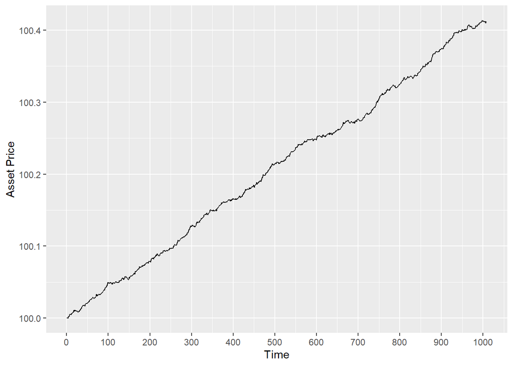

```r
P <- c(P_0, rep(0, length = length(epsilons) -1))

for(i in 1:(length(epsilons)-1)){

  P[i+1] <- P[i] +  mu * delta_t + epsilons[i] * sigma

}

# Plotting the Asset Price

ggplot() +
  geom_line(aes(x = 1:length(epsilons), y = P)) +
  scale_x_continuous(breaks = seq(1,1001,100)-1) +
  labs(x = "Time", y = "Asset Price")
```

```r
# let's make a distribution

P_0 = 100
mu = 0.1
sigma = 0.25
delta_t = 1/252
n_simulation = 1000
lenght_asset = 1000
```

### 2.0.1 Making the simulation function

```r
simulations <- function(P_0 = 100, mu = 0.1,
                        sigma = 0.25, delta_t = 1/252,
                        n_simulation = 1000, lenght_asset = 1000){

  # Creating a matrix to save the simulations
  sim_vector <- matrix(0, nrow = lenght_asset, ncol = n_simulation)

  for(j in seq_len(n_simulation)){

    # Create an empty vector to simulate the asset price path
    P <- c(P_0, rep(0, length = length(lenght_asset)-1))

    # Draw the shock
    epsilons <- rnorm(n_simulation, mean = 0, sd = delta_t)

    # Make a simulation
    for(i in 1:(n_simulation)){

    P[i+1] <- P[i] +  mu * delta_t + rnorm(n = 1, mean = 0, sd = delta_t) * sigma

    # Save the results
    sim_vector[i, j] <- P[i]

    }

  }

  # Returning the matrix
  return(data.frame(sim_vector))
}
```

## 2.1 Making the simulation and plotting

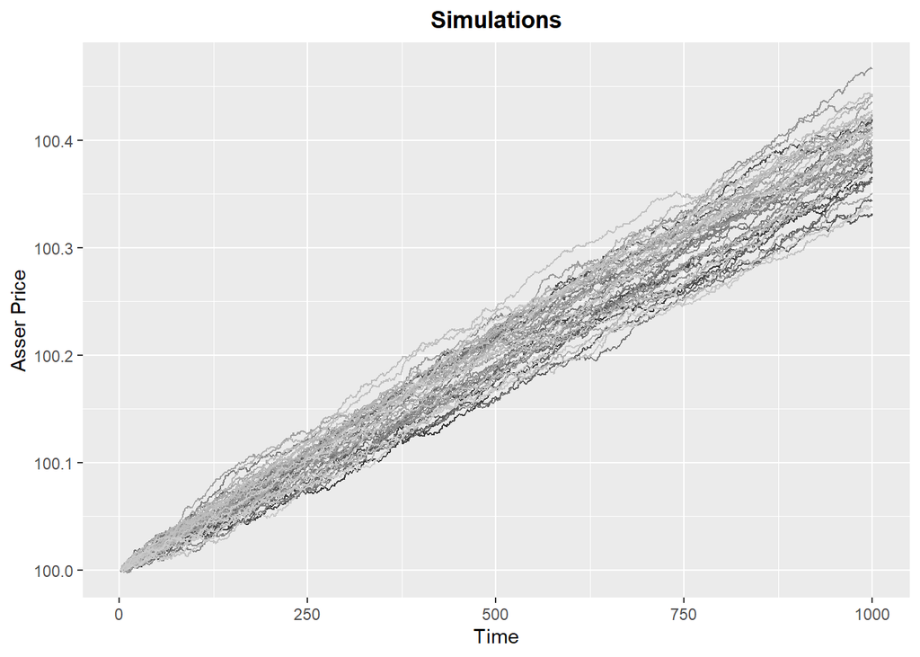

```r
sim <- simulations(P_0 = 100, mu = 0.1,
                   sigma = 0.25, delta_t = 1/252,
                   n_simulation = 1000, lenght_asset = 1000)


# Plotting the first 50 simulations
sim[, 1:50] |>
  mutate(n = seq_len(1000)) |>
  melt(id.vars = "n", variables.name = "variable", value.name = "value") |>
  group_by(variable) |>
  ggplot() +
  geom_line(aes(x = n, y = value, colour = variable)) +
  scale_color_grey() +
  theme(legend.position = "none",
        plot.title = element_text(hjust = 0.5, face = "bold")) +
  labs(x = "Time", y = "Asser Price", title = "Simulations")
```

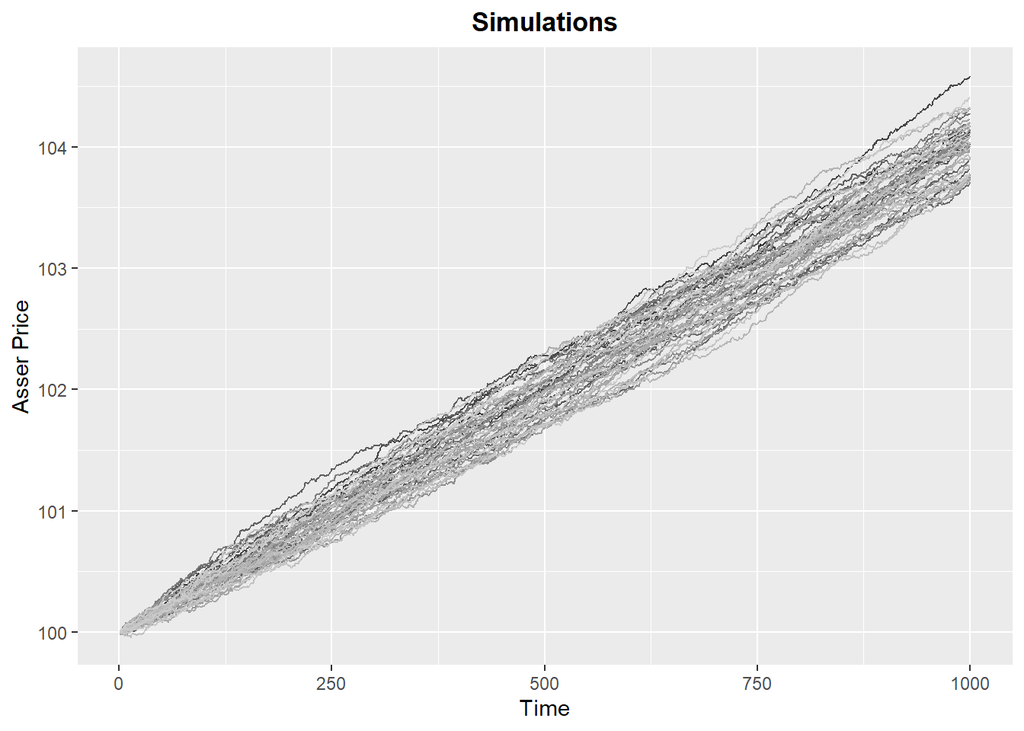

```r
# Making anothers simulation changing parameters

simulations(P_0 = 100, mu = 1,
                   sigma = 2,
                   delta_t = 1/252,
                   n_simulation = 1000,
            lenght_asset = 1000) |>
  select(1:50) |>
  mutate(n = seq_len(1000)) |>
  melt(id.vars = "n", variables.name = "variable", value.name = "value") |>
  group_by(variable) |>
  ggplot() +
  geom_line(aes(x = n, y = value, colour = variable)) +
  scale_color_grey() +
  theme(legend.position = "none",
        plot.title = element_text(hjust = 0.5, face = "bold")) +
  labs(x = "Time", y = "Asser Price", title = "Simulations")
```

# 3 Process 2

- $\Delta P_{t+1} = \mu P_{t} \Delta t + \sigma P_{t} N(0, \Delta t)$

This process is a geometric browning motion that is often used to model the stock price movements, since the variation is relative to the initial point of the stock.

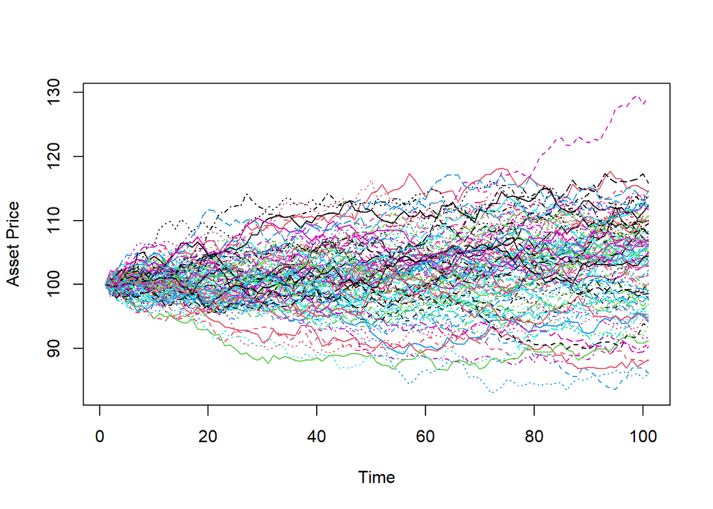

```r
# Function that iterates the process 2

process_2 <- function(p, n_path, mu, delta_t, sigma, p_0){


  p[[1]] <- p_0

  for(i in seq_len(n_path)){

  p[[i+1]] <- p[[i]]*(1 + mu*delta_t + sigma*10*rnorm(n =1, mean = 0, sd = delta_t))

  }

  return(p)

}

# Create an empty list where the simulation will be stored
n_path = 100
n_sim = 100

p <- vector(mode = "list", n_sim)

# Another way to run n simulations

process_2_df <- do.call("rbind",
  lapply(p, function(x) process_2(p = x, n_path = n_path, mu = 0.1, delta_t = 1/252, sigma = 0.20, p_0 = 100))) |>
  as.data.frame() |>
  setNames(c("sim", seq_len(n_sim)))


# A simple way to plot the paths
matplot(process_2_df |> t(), type = "l", ylab= "Asset Price", xlab = "Time")
```

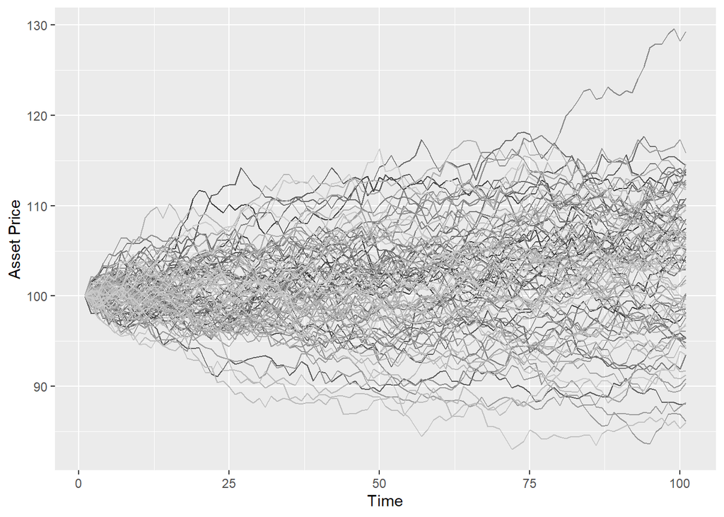

```r
# Plotting all simulations of the Asset Price path
process_2_df |>
  t() |>
  data.frame() |>
  mutate(n = 1:(n_sim+1)) |>
  gather(-c("n"), key = "variable", value = "value") |>
  mutate(value = as.numeric(value)) |>
  group_by(variable) |>
  ggplot() +
  geom_line(aes(x = n, y = value, colour = variable)) +
  theme(legend.position = "none") +
  labs(x = "Time", y = "Asset Price") +
  scale_colour_grey()
```

### 3.0.1 Process 3:

- $\Delta P_{t+1} = \mu(\bar{P} - P_{t}) \Delta t + \sigma P_{t} N(0, \Delta t)$

This process is a geometric browning motion with normalized drift. Note that for a price level higher than $\bar{P}$ the drift becomes negative and the process start to converge to the mean. The inverse happens when $P_{t} > \bar{P}$. This process may not be acceptable to model stock prices, since its expected an positive growth. But it may be adequate to model interest rate since its a stationary variable.

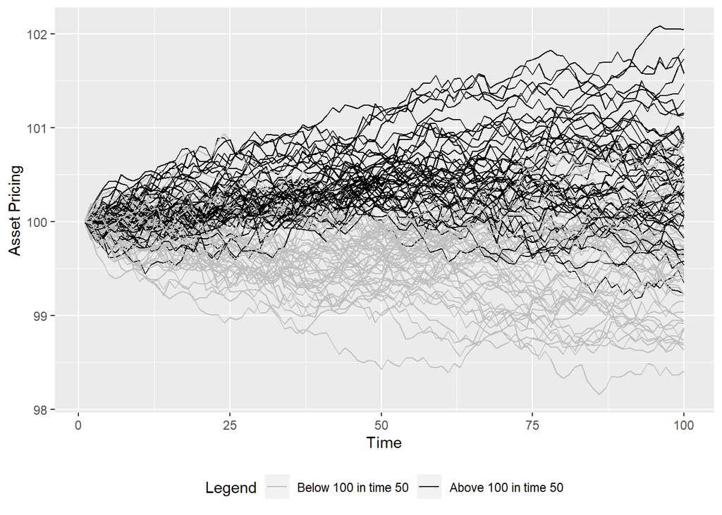

```r
process_3 <- function(n_sim = 100, time_length = 100, p_0 = 100,
                      mu = 0.1, delta_t = 1/252, sigma= 0.2){

  dt_process_3 <- matrix(NA, nrow = time_length, ncol = n_sim)

  dt_process_3[1, ] <- p_0

  for(j in seq_len(n_sim)){

    for(i in seq_len(time_length-1)){

      dt_process_3[i+1, j] <- dt_process_3[i, j] +
        mu*(mean(dt_process_3[, j], na.rm = T) - dt_process_3[i, j])*delta_t +
        dt_process_3[i, j]*sigma*rnorm(n = 1, mean = 0, sd = delta_t)

    }

  }

  dt_process_3 <- data.frame(dt_process_3)
  return(dt_process_3)
}

dt_3 <- process_3(n_sim = 100)


# Plotting Asset Price Path with an addition
# The path in black are those with value higher than 100 in the middle of time, those in grey are below 100. Counting the path in black gives the probability of the asset price being above 100. It is plot visualization of the exercise asked in tutorial 2.

dt_3 |>
  mutate(sim = seq_len(100)) |>
  tidyr::gather(-c("sim"), key ="variable", value = "value") |>
  group_by(variable) |>
  mutate(high = ifelse(sim == 50 & value > 100,1,0),
         high = max(high)) |>
  group_by(variable, high) |>
  ggplot() +
  geom_line(aes(x = sim, y = value, group = variable, colour = as.factor(high))) +
  labs(x = "Time", y = "Asset Pricing") +
  scale_colour_manual(values = c("grey", "black"),
                     labels = c("Below 100 in time 50", "Above 100 in time 50"),
                     name = "Legend") +
  theme(legend.position = "bottom")
```

### 3.0.2 Process 4:

- $\Delta P_{t+1} = \mu P_{t} \Delta t + \sigma P_{t} N(\Delta P_{t}/P_{t-1}, \Delta t)$

This process have the same drift of a Geometric Brownian motion, the disturbance that is different. When returns are positive the shock becomes, on average, positive, implying in an increase in the asset price.

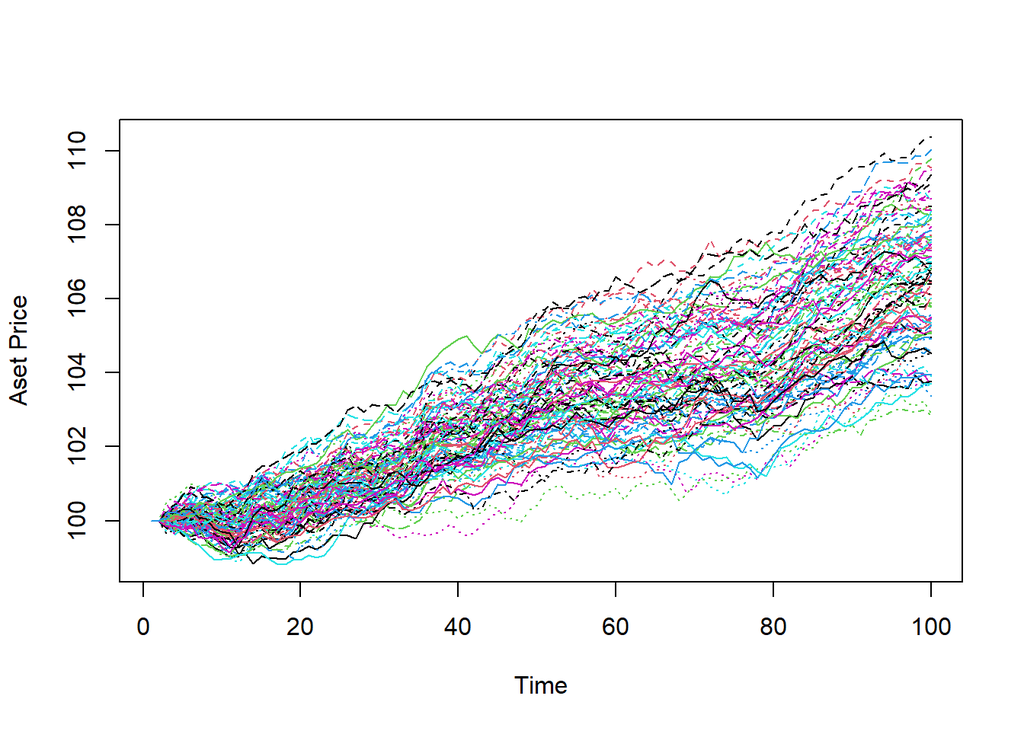

```r
length_path <- 100  # Number of steps in asset price simulation
n_sim <- 100        # Number of Simulation

# Parameters of the simulations

mu <- 0.1
delta_t <- 1/252
sigma <- 0.4


# Making the simulation

process_4 <- matrix(data = NA, nrow = length_path, ncol = n_sim)

# Filling the first and second row with initial Price P_0
process_4[1:2, ] <- P_0


# Making the simulation
# J is the simulation
# i is time

for(j in seq_len(n_sim)){

  for(i in seq(from = 3, to = n_sim, by = 1)){

    process_4[i, j] <- process_4[i-1, j]*(1 + mu * delta_t + sigma*rnorm(n = 1, mean = (process_4[i-1]- process_4[i-2])/process_4[i-2], sd = delta_t))

  }
}

matplot(y = process_4, type = "l", xlab =  "Time", ylab = "Aset Price")
```

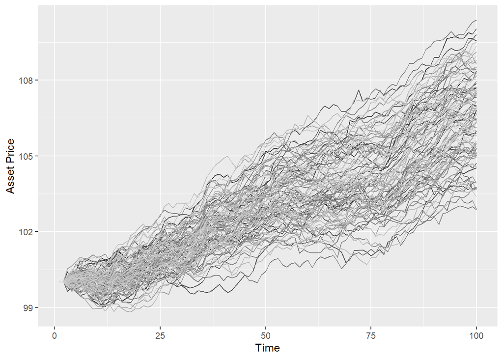

```r
# Plotting Asset Price path

process_4 |>
  data.frame() |>
  mutate(time = seq(from = 1, to = length_path, by = 1)) |>
  gather(-c("time") , key = "simulation", value = "value") |>
  ggplot() +
  geom_line(aes(x = time, y = value, colour = simulation)) +
  theme(legend.position = "none") +
  labs(x = "Time", y = "Asset Price") +
  scale_colour_grey()
```

### 3.0.3 Process 5:

- $\Delta P_{t+1} = \mu( \bar{P} - P_{t}) \Delta t + \sigma P_{t} N_{1}(0, \Delta t) + \sigma_{j}Bern(p)P_{t} N_{2}(0, \Delta t)$ where, $N_{1}, N_{2}$ are independent and $Bern(p)$ is a Bernoulli with probability $p$ at the interval $\Delta_{t}$

This process is crazy with jumps

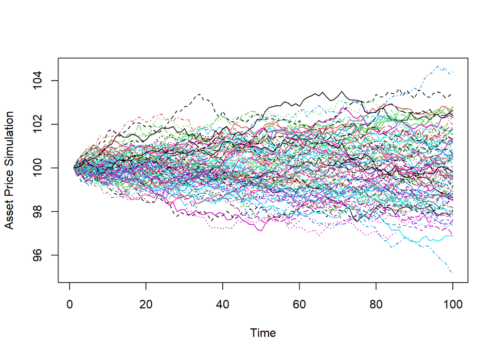

```r
length_path <- 100  # Number of steps in asset price simulation
n_sim <- 100        # Number of Simulation

# Parameters of the simulations

mu <- 0.1         # Annual Expected Returns
delta_t <- 1/252  # Time fraction
sigma <- 0.4      # Annual Volatility
P_0 <- 100        # Initial Price


# Making the simulation

process_5 <- matrix(data = NA, nrow = length_path, ncol = n_sim)

# Setting the first row of the matrix equal the initial price
process_5[1, ] <- P_0

# Making the simulation
# J is the simulation
# i is time

for(j in seq_len(n_sim)){

  for(i in seq(from = 2, to = length_path, by = 1)){

    process_5[i, j] <- process_5[i-1, j] + mu*(mean(process_5, na.rm = T) - process_5[i-1, j]) * delta_t +
      process_5[i-1, j]*sigma*rnorm(n = 1, mean = 0, sd = delta_t) +
      sigma*rbinom(n = 1 , size = 1, prob = 0.5)*rnorm(n = 1, mean = 0, sd = delta_t)

  }

}

# Simple way to plot the simulations

matplot(process_5, type = "l", xlab = "Time", ylab = "Asset Price Simulation")
```

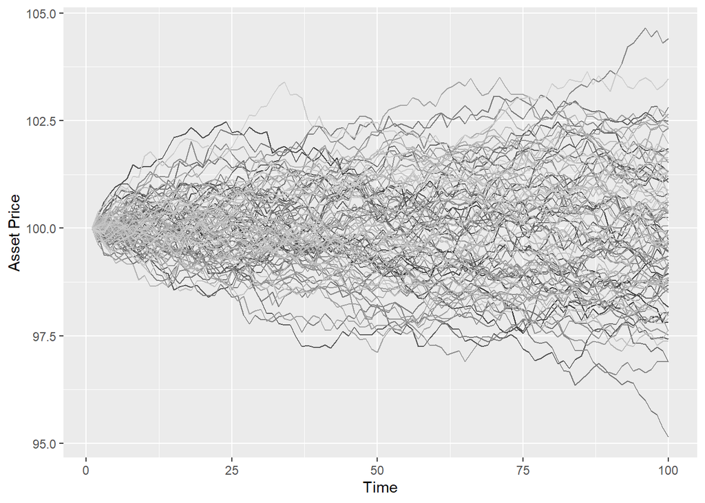

```r
# Plotting Asset Price path

process_5 |>
  data.frame() |>
  mutate(time = seq(from = 1, to = length_path, by = 1)) |>
  gather(-c("time") , key = "simulation", value = "value") |>
  ggplot() +
  geom_line(aes(x = time, y = value, colour = simulation)) +
  theme(legend.position = "none") +
  labs(x = "Time", y = "Asset Price") +
  scale_colour_grey()
```